# Good DATA2x02 teammates characteristics

- Show All Code
- Hide All Code
- View Source

Author

530604594

Published

September 8, 2024

```r
knitr::opts_chunk$set(echo = TRUE)
library(tidyverse)
library(gendercoder)
library(janitor)
library(gt)
library(visdat)
library(knitr)
library(reshape2)
library(patchwork)
library(ggpubr)
# bibtex file for packages used:
knitr::write_bib(c(.packages(),
                   "knitr", "rmarkdown"), "refs/packages.bib")
# extra bibliography in bibliography.bibtex
```

## 1 Introduction

Tarr (2024b) looked at the online survey completed voluntarily by the 2024 S2 cohort of DATA2x02, totaling 313 responses for 49 question. The end result is stored in a .xlsx file, exported from Google form. Figure 1. The responses are unlikely to be a completely random sample of DATA2x02 students. Since the survey is completed voluntarily on Edstem, the survey is subject to non-random participation. This survey may over-represent students who are interested in the subject and those who frequently open their Ed discussions.

Aside from the bias mentioned above, many variables in this survey are subject to other biases. Questions regarding WAM and others of similar sensitive nature are subject to the sensitive question bias, where participants may disclose a false result out of embarrassment. Questions like “what is your shoe’s size” are affected by the misinterpretation bias due to not standardizing results (is the shoe size to be measured to European or American standard?). The survey is 49 questions long, leading to survey fatigue bias where the participants feel tired from doing such a long survey and start answering later questions with less care than the first ones. This list is not an exhaustive list of possible biases but a list that the author believes to be most significant.

As a result, some questions can be improved for better data collection in the future. Questions on numerical values like “age” and “height” should have data validation for integer values only to avoid results like “20+”. Questions like “country” should be a radio button list to avoid discrepancies like “Australia” and “Australia!”. The question on gender should also be a radio button list instead of free form response to avoid offensive inputs and standardization issues. Questions like “allergies” should be of type multiple choices response or integer validation. Questions like the one about shoe size should specify the scale it is using to avoid confusion. This list is not an exhaustive list of possible fixes but a list that the author believes to be most significant.

From these result, this report will attempt to identify traits that are most indicative of being a good team member, hoping to help others in choosing their own team for the upcoming group assignment for DATA2x02.

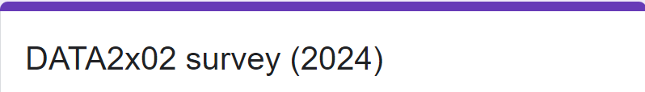

Figure 1: The survey on Google Form

### 1.1 Data Wrangling

The calculations in this report were performed in R (R Core Team 2024) within the Rmarkdown environment (Xie, Allaire, and Grolemund 2018) for reproducibility. Data wrangling was performed in base R and the tidyverse (Wickham et al. 2019) and janitor (Firke 2023). Graphs were produced with ggplot2 (Wickham et al. 2019) except for the missing value visualization made with the visdat package (Tierney 2023) and the Q-Q plots which were made with the ggpubr package (Kassambara 2023). Tables were made using the gt package (Iannone et al. 2024) and cleaning matrices into data frame used the reshape2 package (Wickham 2020). The patchwork package was used to display plots side by side (Pedersen 2024).

Names of the variables were cleaned and shortened. Responses values are also cleaned, shortened and categorized. The gender variable cleaning and renaming is based on Tarr (2024a). Missing and nonsensical values were not removed at this stage, but will dealt with on a case by case basis, to conserve as much data as possible for analysis.

| New | Old |
| --- | --- |
| timestamp | Timestamp |
| target_grade | What final grade are you aiming to achieve in DATA2x02? |
| assignment_preference | When it comes to assignments / due tasks do you: |
| trimester_or_semester | Would you prefer to have a trimester system (3 main teaching sessions per year) or stick with the existing semester system (2 main teaching sessions per year)? |
| age | How old are you? |
| tendency_yes_or_no | Do you tend to lean towards saying "yes" or towards saying "no" to things throughout life? |
| pay_rent | Do you pay rent? |
| urinal_choice | You enter a public bathroom and find you're the only one there. There are three urinals on the wall for you to choose from. Which do you choose? |
| stall_choice | You enter a public bathroom and there are three stalls to choose from. All three are unoccupied. Which do you choose? |
| weetbix_count | How many Weet-Bix would you typically eat in one sitting? |
| weekly_food_spend | What is the average amount of money you spend each week on food/beverages? |
| living_arrangements | What are your current living arrangements? |
| weekly_alcohol | How much alcohol do you consume each week? |
| believe_in_aliens | Do you believe in the existence of aliens (Extraterrestrial Life)? |
| height | How tall are you? |
| commute | How do you get to university? |
| daily_anxiety_frequency | How often would you say you feel anxious on a daily basis? |
| weekly_study_hours | How many hours a week do you spend studying? |
| work_status | Do you work? |
| social_media | What is your favourite social media platform? |
| gender | What is your gender? |
| average_daily_sleep | How much sleep do you get (on avg, per day)? |
| usual_bedtime | What time do you usually go to bed? |
| sleep_schedule | How consistent would you rate your sleep schedule? |
| sibling_count | How many siblings do you have? |
| allergy_count | How many allergies do you know you have? |
| diet_style | What is your diet style? |
| random_number | Pick a number at random between 1 and 10 (inclusive) |
| favourite_number | What is your favourite number (between 1 and 10 inclusive) |
| favourite_letter | What is your favourite letter from the English alphabet? |
| drivers_license | Do you have a driver's license? |
| relationship_status | Do you currently have a partner? |
| daily_short_video_time | How much time do you spend on short video apps (like tiktok or reels) every day? |
| computer_os | What computer OS (operating system) are you currently using? |
| steak_preference | How do you like your steak cooked? |
| dominant_hand | What is your dominant hand? |
| enrolled_unit | Which unit are you enrolled in? |
| weekly_exercise_hours | On average, how many hours each week do you spend exercising? |
| weekly_paid_work_hours | How many hours a week (on average) do you work in paid employment? |
| assignments_on_time | Do you submit assignments on time? |
| used_r_before | Have you ever used R before starting DATA2x02? |
| team_role_type | What kind of role (active or passive) do you think you are when working as part of a team? |
| university_year | Which year of university are you currently in? |
| favourite_anime | What is your favourite anime? |
| fluent_languages | How many languages can you speak fluently? |
| readable_languages | How many languages can you read? |
| country_of_birth | What country were you born in? |
| wam | What is your WAM (weighted average mark)? |
| shoe_size | What is your shoe size? |

| Original outcomes | Recoded outcomes boy | Recoded outcomes girl | Recoded outcomes man | Recoded outcomes woman | NA_ |  |
| --- | --- | --- | --- | --- | --- | --- |
| 100.0 | 0 | 0 | 0 | 0 |  | 1 |
| Biological Female | 0 | 0 | 0 | 0 | 1 |  |
| boy | 1 | 0 | 0 | 0 | 0 |  |
| cis male | 0 | 0 | 1 | 0 | 0 |  |
| Cisgender | 0 | 0 | 0 | 0 | 1 |  |
| f | 0 | 0 | 0 | 3 | 0 |  |
| F | 0 | 0 | 0 | 2 | 0 |  |
| Fem | 0 | 0 | 0 | 1 | 0 |  |
| femal | 0 | 0 | 0 | 1 | 0 |  |
| female | 0 | 0 | 0 | 51 | 0 |  |
| Female | 0 | 0 | 0 | 62 | 0 |  |
| girl | 0 | 1 | 0 | 0 | 0 |  |
| Heterosexual Male | 0 | 0 | 0 | 0 | 1 |  |
| m | 0 | 0 | 1 | 0 | 0 |  |
| M | 0 | 0 | 4 | 0 | 0 |  |
| male | 0 | 0 | 51 | 0 | 0 |  |
| Male | 0 | 0 | 109 | 0 | 0 |  |
| MALE | 0 | 0 | 2 | 0 | 0 |  |
| man | 0 | 0 | 1 | 0 | 0 |  |
| Man | 0 | 0 | 1 | 0 | 0 |  |
| n/a | 0 | 0 | 0 | 0 | 1 |  |
| Not Female | 0 | 0 | 0 | 0 | 1 |  |
| woman | 0 | 0 | 0 | 2 | 0 |  |
| NA | 0 | 0 | 0 | 0 | 13 |  |

We check for missing values via Figure 2. There does not seem to have many missing data values. Two categories stands out with significantly more missing values than the rest: favourite_anime and wam. This is likely due to people not watching anime and sensitive question bias for both.

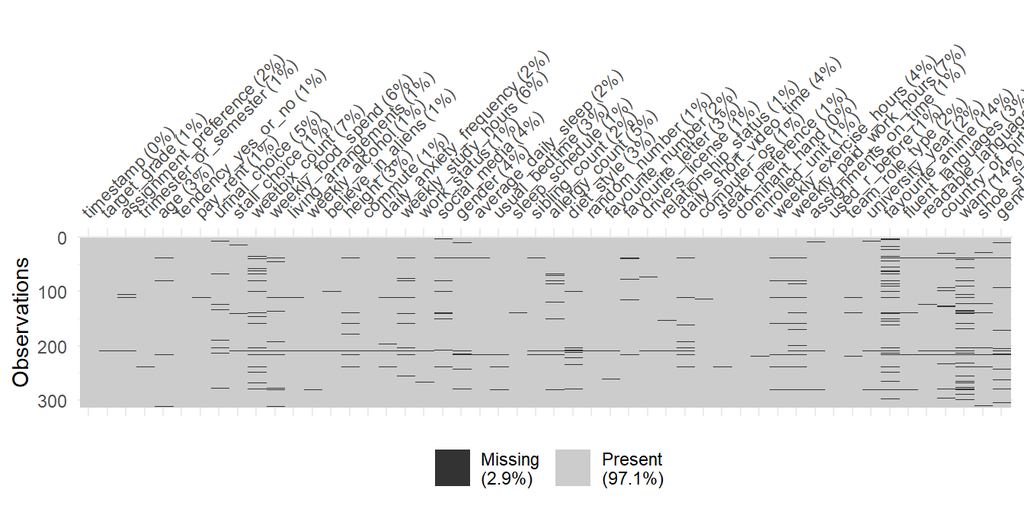

Figure 2: Missing values of the responses

```r
# Generate visualisation for missing data
visdat::vis_miss(data2x02) +
  theme(aspect.ratio = 0.2) +
  theme(axis.text.data2x02 = element_text(angle = 90, hjust = 0))
```

## 2 Results

### 2.1 Is WAM significantly different at the p < 0.05 level between *DATA2002* and *DATA2902* students?

```r
# Remove rows where 'wam' and 'enrolled_unit' is NA or nonsensical
data2x02_wam_cohort <- data2x02 %>% filter(!is.na(wam) & !is.na(enrolled_unit))
# WAM of less than 50 is nonsensical, shouldn't pass to take DATA2x02
data2x02_wam_cohort <- data2x02_wam_cohort %>% filter(wam >= 50)
data2x02_wam_cohort$enrolled_unit <- factor(data2x02_wam_cohort$enrolled_unit)

# Create table
formatted = data2x02_wam_cohort %>% select(wam, enrolled_unit) %>% group_by(enrolled_unit) %>%
  summarise(n = n(),
            Mean = mean(wam) %>% signif(2),
            SD = sd(wam) %>% signif(2)
            )
colnames(formatted)[colnames(formatted) == 'enrolled_unit'] <- 'Enrolled unit'
knitr::kable(formatted)
```

| Enrolled unit | n | Mean | SD |
| --- | --- | --- | --- |
| DATA2002 | 208 | 74 | 8.9 |
| DATA2902 | 50 | 82 | 7.5 |

Figure 3: Table of WAM mean and sd, separated by unit

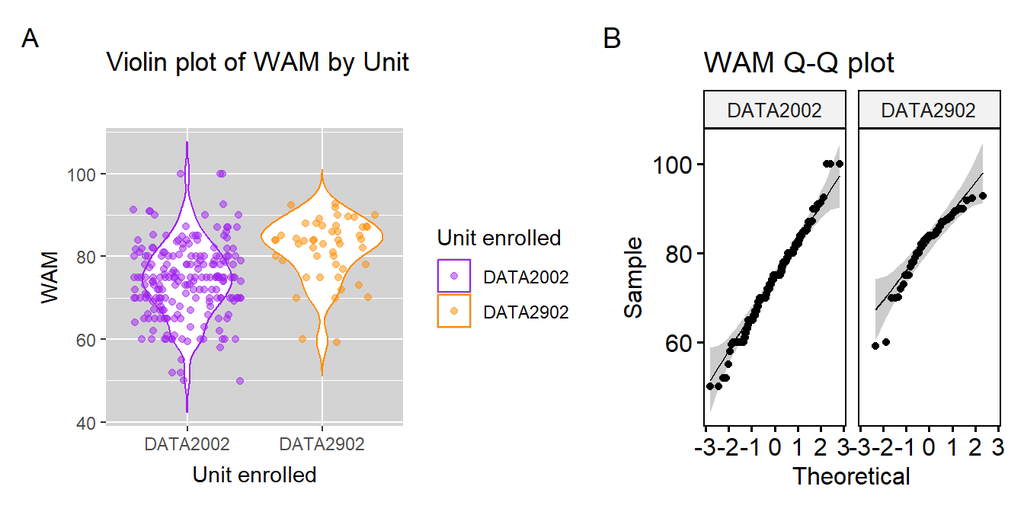

Figure 4: WAM distribution, checking for normality and symmetry **A**: Violin plot **B**: Q-Q plot

```r
data2x02_wam_cohort_2002 = data2x02_wam_cohort %>% filter(enrolled_unit == "DATA2002")
data2x02_wam_cohort_2902 = data2x02_wam_cohort %>% filter(enrolled_unit == "DATA2902")

# Side-by-side violin plots comparing WAM by Unit
p1 <-  ggplot(data2x02_wam_cohort, aes(x = enrolled_unit, y = wam, fill = enrolled_unit, color = enrolled_unit)) +
  geom_violin(trim = FALSE, width = 0.9, fill = "white") +
  labs(title = "Violin plot of WAM by Unit",
       x = "Unit enrolled",
       y = "WAM",
       fill = "Unit enrolled",
       color = "Unit enrolled") +
  geom_jitter(alpha = 0.5) +
  scale_color_manual(values = c("purple","darkorange")) +
  theme(
    panel.background = element_rect(fill = "lightgrey", color = NA),
    panel.grid.major = element_line(color = "white"),
    panel.grid.minor = element_line(color = "white")
  )

# Double Q-Q plot
p2 <-  ggqqplot(data2x02_wam_cohort, x = "wam", facet.by = "enrolled_unit") + labs(title = "WAM Q-Q plot")

p1 + p2 + plot_annotation(tag_levels = 'A')
```

```r
myTest <- wilcox.test(wam ~ enrolled_unit, data = data2x02_wam_cohort, alternative = "less")
```

### 2.2 Is grade aim and assignment submission preferences dependent at the p < 0.05 level?

Many people believe that there is a relationship between your approach to assignment submission and your grade aim. It is common sense to assume that someone who aims toward a higher score would be more proactive in their study and therefore would like to submit early. We test this claim at the p = 0.05 significant level.

```r
# Filter out NA values and remove nonsensical data
data2x02_tg_ap <- data2x02 %>% filter(!is.na(target_grade) & !is.na(assignment_preference))

# Unlikely that someone is aiming to fail
data2x02_tg_ap <- data2x02_tg_ap %>% filter(!(target_grade == 'Fail'))

# Ordering target_grade
data2x02_tg_ap$target_grade <- factor(data2x02_tg_ap$target_grade, levels = c("Pass", "Distinction", "High Distinction"), ordered = TRUE)

# Reassigning assignment preference values to "cram" and "no cram"
data2x02_tg_ap$assignment_preference <- ifelse(data2x02_tg_ap$assignment_preference == "cram", "cram", "no cram")

# Create a contingency tables
contingency_table <- table(data2x02_tg_ap$target_grade, data2x02_tg_ap$assignment_preference)
knitr::kable(contingency_table)
```

|  | cram | no cram |
| --- | --- | --- |
| Pass | 5 | 5 |
| Distinction | 39 | 63 |
| High Distinction | 36 | 126 |

Figure 5: Table of grade aim and assignment preferences frequency

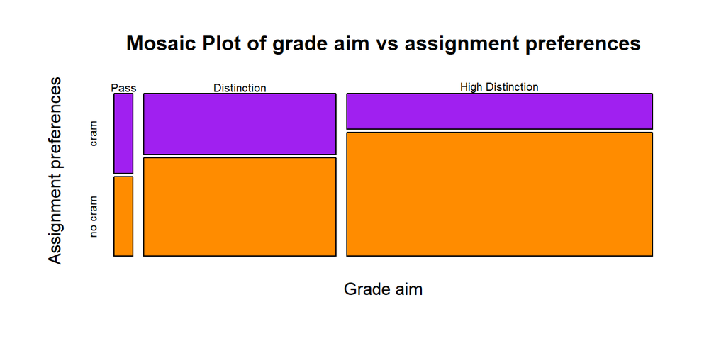

Figure 6: Mosaic plot of grade aim and assignment preferences frequency

```r
# Create a mosaic plot
mosaicplot(contingency_table, main = "Mosaic Plot of grade aim vs assignment preferences",
           xlab = "Grade aim", ylab = "Assignment preferences", col = c("purple","darkorange"))
```

```r
# Chi-Square test of independence
chi_test_result <- chisq.test(contingency_table)
# Extract the expected values, check for > 5 status
expected <- chi_test_result$expected
knitr::kable(expected > 5)
```

|  | cram | no cram |
| --- | --- | --- |
| Pass | FALSE | TRUE |
| Distinction | TRUE | TRUE |
| High Distinction | TRUE | TRUE |

Table of expected values > 5 status

1. **Hypothesis:** $H_0:$ assignment preferences and grade aim is independent vs $H_1:$ There is dependence between assignment preferences and grade aim.
2. **Assumptions:** From the table generated above, we can conclude that Cochran’s assumption is valid here as the number of cells with a expected value of lower than 5 is less than 20%. Therefore, Pearson’s Chi-square test is preferred.
3. **Test statistic:** $T = \sum_{i=1}^{a} \sum_{j=1}^{b} \frac{(O_{ij} - E_{ij})^2}{E_{ij}}$. Under $H_0, T \sim \chi^2_{(a-1)(b-1)}$.

```r
t0 <- chisq.test(contingency_table)
```

4. **Observed test statistic:** $t_0 =$ 9.94 with 2 degrees of freedom

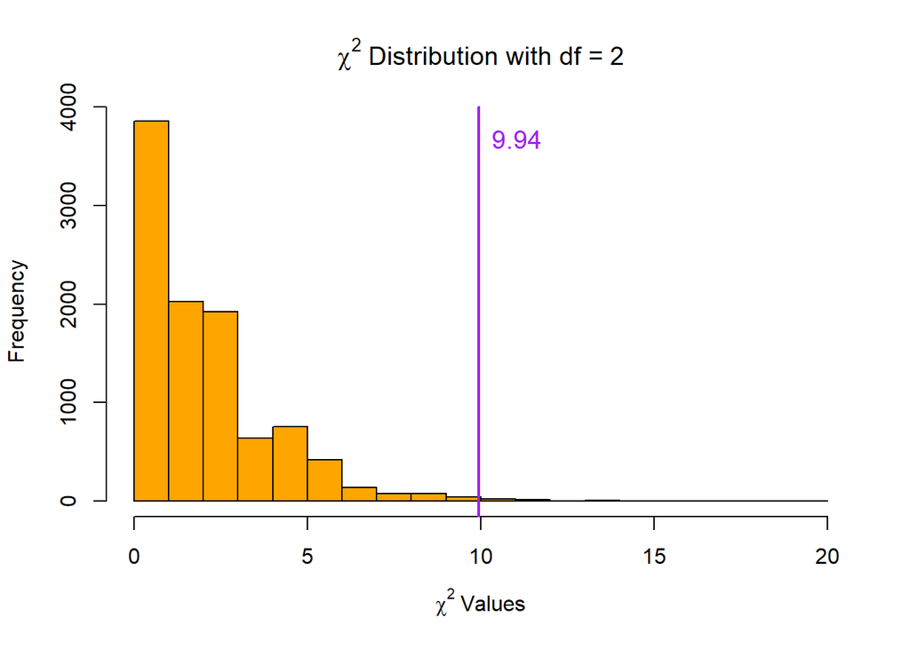

Figure 7: chi^2 ~ “Distribution”

```r
# Randomly create tables for Chi-square distribution
set.seed(1)
B = 10000

x_list = r2dtable(n = B,
                  r = rowSums(contingency_table),
                  c = colSums(contingency_table))

rnd.chisq = numeric(B)

for (i in 1:B) {
  rnd.chisq[i] = chisq.test(x_list[[i]])$statistic
}

# Create histogram
hist(rnd.chisq,
     col = "orange",
     xlab=expression(chi^2 ~ "Values"),
     main = bquote(chi^2 ~ "Distribution with df =" ~ .(t0$parameter)))

abline(v = signif(t0$statistic,3), col = "purple", lwd = 2)

text(x = signif(t0$statistic, 3),
     y = max(hist(rnd.chisq, plot = FALSE)$counts) * 0.95,
     labels = round(signif(t0$statistic, 3), 2),
     col = "purple",
     pos = 4,
     cex = 1.2)
```

5. **p-value**: $P(\chi^2_2 \ge 9.94) = 0.007$
6. **Decision**: Reject in $H_0$ favor of $H_1$, as the observed p-value, 0.007, is smaller than the 5% critical threshold. The data supports the belief that there is dependency between assignment preferences and grade aim. Looking at the mosaic plot Figure 6, we can see that students who took a more proactive approach to assignment submission are more likely to have higher grade aim, a desirable characteristic in a teammate.

### 2.3 Is there a significant difference in hours of study at the p-value = 0.05 level between nationality, controlled for gender?

Since the group project holds such weight, finding teammates is incredibly important. However, this may lead to discrimination against people of different nationalities and gender, with some groups being favored and others shunned. As a result, this report would like to amend this problem by checking whether these biases have any basis.

We categorize nationality into continents due to the low cell counts of some countries before taking a look at the two most prominent groups here (Oceania and Asia). We divide study hours per week into quantiles for ease of analysis.

```r
# Filter out NA values and remove nonsensical data
data2x02_ngh <- data2x02 %>% filter(!is.na(gender_clean) & !is.na(country_of_birth) & !is.na(weekly_study_hours))

# Unlikely to have students from North Korea, most people should study at least 2 hours a day due to mandatory university lectures and less than 10 hours a day to have 6 hours for rest and other activities.
data2x02_ngh <- data2x02_ngh %>% filter(country_of_birth != "North Korea")
data2x02_ngh <- data2x02_ngh %>% filter(14 < weekly_study_hours & weekly_study_hours < 70)


# Adding continent category
data2x02_ngh$continent[data2x02_ngh$country_of_birth == "australia"] <- "Oceania"
data2x02_ngh$continent[data2x02_ngh$country_of_birth == "new zealand"] <- "Oceania"

data2x02_ngh$continent[data2x02_ngh$country_of_birth %in% c("china", "india", "malaysia", "pakistan", "thailand",
                                               "indonesia", "vietnam", "hongkong", "myanmar",
                                               "singapore", "bangladesh", "uae", "israel",
                                               "south korea", "taiwan", "japan", "north korea",
                                               "philippines")] <- "Asia"

data2x02_ngh$continent[data2x02_ngh$country_of_birth %in% c("usa", "america")] <- "North America"

data2x02_ngh$continent[data2x02_ngh$country_of_birth %in% c("england", "denmark", "germany", "france")] <- "Europe"

data2x02_ngh$continent[data2x02_ngh$country_of_birth == "south africa"] <- "Africa"

# Adding study hours quantiles
data2x02_ngh$quartile <- cut(
  data2x02_ngh$weekly_study_hours,
  breaks = quantile(data2x02_ngh$weekly_study_hours, probs = seq(0, 1, by = 1/4), na.rm = TRUE),
  include.lowest = TRUE,
  labels = c("Q1", "Q2", "Q3", "Q4")
)
```

```r
# Split data into male and female data sets
data2x02_ngh_m <- data2x02_ngh %>% filter(gender_clean == "man")
data2x02_ngh_f <- data2x02_ngh %>% filter(gender_clean == "woman")

# Filter for Oceanic and Asian students
subset_data <- subset(data2x02_ngh_m, continent %in% c("Asia", "Oceania"))

# Create a contingency table for male data set
contingency_table1 <- table(subset_data$quartile, subset_data$continent)
knitr::kable(contingency_table1)
```

|  | Asia | Oceania |
| --- | --- | --- |
| Q1 | 19 | 21 |
| Q2 | 11 | 3 |
| Q3 | 15 | 2 |
| Q4 | 17 | 6 |

Figure 8: Table of continents and study hours per week count for male students

```r
# Filter for Oceanic and Asian students
subset_data <- subset(data2x02_ngh_f, continent %in% c("Asia", "Oceania"))

# Create a contingency table for female
contingency_table2 <- table(subset_data$quartile, subset_data$continent)
knitr::kable(contingency_table2)
```

|  | Asia | Oceania |
| --- | --- | --- |
| Q1 | 13 | 8 |
| Q2 | 9 | 1 |
| Q3 | 16 | 5 |
| Q4 | 12 | 2 |

Figure 9: Table of continents and study hours per week count for female students

From the tables generated, we can conclude that Cochran’s assumption is valid for the male data set as less than 20% of the cells have a expected value of lower than 5 (@Figure 10) but not for the female data set (Figure 11). Therefore, the female data set will be analysed using Monte Carlo simulation instead.

```r
# Chi-Square test of independence for male data set
chi_test_result1 <- chisq.test(contingency_table1)

# Extract the expected values, check for > 5 status
expected1 <- chi_test_result1$expected > 5
knitr::kable(expected1)
```

|  | Asia | Oceania |
| --- | --- | --- |
| Q1 | TRUE | TRUE |
| Q2 | TRUE | FALSE |
| Q3 | TRUE | TRUE |
| Q4 | TRUE | TRUE |

Figure 10: Table of Chi-square expected values > 5 status for male students

```r
# Chi-Square test of independence for female data set
chi_test_result2 <- chisq.test(contingency_table2)

# Extract the expected values, check for > 5 status
expected2 <- chi_test_result2$expected > 5
knitr::kable(expected2)
```

|  | Asia | Oceania |
| --- | --- | --- |
| Q1 | TRUE | TRUE |
| Q2 | TRUE | FALSE |
| Q3 | TRUE | TRUE |
| Q4 | TRUE | FALSE |

Figure 11: Table of Chi-square expected values > 5 status for female students

The heat maps generated here (Figure 12) show a general trend of students from Oceania more often reporting themselves from the lowest quantile of study hours than expected and students from Asia reporting themselves more frequently from higher quantiles than expected.

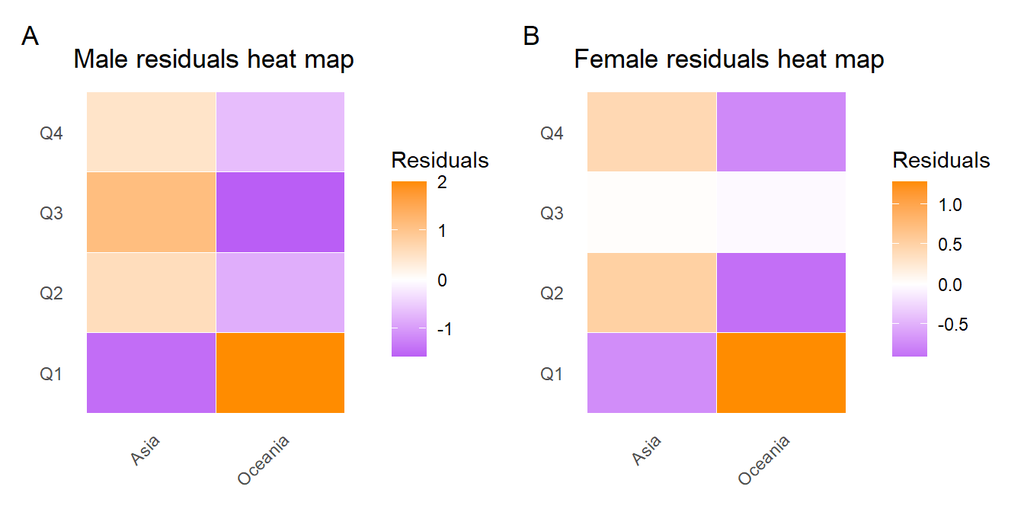

Figure 12: Heat maps of Chi-square tests residuals for male and female student of Oceania and Asia **A**: Male **B**: Female

```r
# Melting matrices into data frames
data_melt1 <- melt(chi_test_result1$residuals)
data_melt2 <- melt(chi_test_result2$residuals)

# Create the heat maps with ggplot2
# Male heat map
plot1 <- ggplot(data_melt1, aes(x = Var2, y = Var1, fill = value)) +
  geom_tile(color = "white") +
  scale_fill_gradient2(low = "purple", high = "darkorange", mid = "white", midpoint = 0,
                       limit = c(min(data_melt1$value), max(data_melt1$value)),
                       name = "Residuals") +
  theme_minimal() +
  theme(axis.title.x = element_blank(),
        axis.title.y = element_blank(),
        panel.grid.major = element_blank(),
        panel.border = element_blank(),
        axis.text.x = element_text(angle = 45, hjust = 1)) +
  ggtitle("Male residuals heat map")

# Female heat map
plot2 <- ggplot(data_melt2, aes(x = Var2, y = Var1, fill = value)) +
  geom_tile(color = "white") +
  scale_fill_gradient2(low = "purple", high = "darkorange", mid = "white", midpoint = 0,
                       limit = c(min(data_melt2$value), max(data_melt2$value)),
                       name = "Residuals") +
  theme_minimal() +
  theme(axis.title.x = element_blank(),
        axis.title.y = element_blank(),
        panel.grid.major = element_blank(),
        panel.border = element_blank(),
        axis.text.x = element_text(angle = 45, hjust = 1)) +
  ggtitle("Female residuals heat map")

plot1 + plot2 + plot_annotation(tag_levels = 'A')
```

#### 2.3.1 Male dataset

```r
chiqMF <- chisq.test(contingency_table1)
```

1. **Hypotheses**: $H_0$: The proportion of students’ study hours quantiles are the same for both male students from Oceania and Asia vs $H_1$: The ratio are not the same.
2. **Assumptions**: $e_i$ = $np_i \ge 5$, which we have checked and confirmed to be true for more than 80% of all cells (Figure 10).
3. **Test statistic**: $T = \sum_{i=1}^{a} \sum_{j=1}^{b} \frac{(O_{ij} - E_{ij})^2}{E_{ij}}$. Under $H_0, T \sim \chi^2_{(a-1)(b-1)}$.
4. **Observed test statistic**: $t_0$ = 11

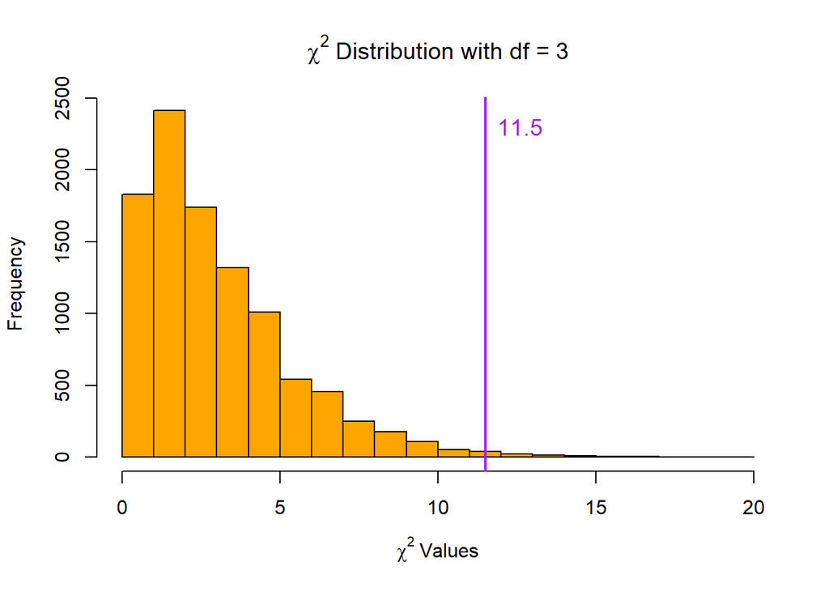

Figure 13: chi^2 ~ “Distribution”

```r
# Randomly create tables for Chi-square distribution

set.seed(1)
B = 10000

x_list = r2dtable(n = B,
                  r = rowSums(contingency_table1),
                  c = colSums(contingency_table1))

rnd.chisq = numeric(B)

for (i in 1:B) {
  rnd.chisq[i] = chisq.test(x_list[[i]])$statistic
}

# Make histogram
hist(rnd.chisq,
     col = "orange",
     xlab=expression(chi^2 ~ "Values"),
     main = bquote(chi^2 ~ "Distribution with df =" ~ .(chiqMF$parameter)))

abline(v = signif(chiqMF$statistic,3), col = "purple", lwd = 2)

text(x = signif(chiqMF$statistic, 3),
     y = max(hist(rnd.chisq, plot = FALSE)$counts) * 0.95,
     labels = round(signif(chiqMF$statistic, 3), 2),
     col = "purple",
     pos = 4,
     cex = 1.2)
```

5. **p-value**: $P(\chi^2_3 \ge$ 11 ) = 0.00945
6. **Decision**: Since the p-value is much smaller than the 5% threshold, we reject $H_0$ and accept that there are evidence supporting the claim that the study hours quantiles ratio are not the same between Asia and Oceania. Looking at the heat map on the left of (Figure 12), we see evidence that Male Asian students are more likely to report higher study hours per week than their Oceania peers, a preferred characteristic in teammates.

#### 2.3.2 Female dataset

```r
set.seed(1)
chiqMF <- chisq.test(contingency_table2, simulate.p.value = TRUE, B = 20000)
```

1. **Hypotheses**: $H_0$: The proportion of students’ study hours quantiles are the same for both female students from Oceania and Asia vs $H_1$: The ratio are not the same.
2. **Assumptions**: Monte Carlo simulations allow this test to be non-parametric and requires no assumptions.
3. **Test statistic**: $T = \sum_{i=1}^{a} \sum_{j=1}^{b} \frac{(O_{ij} - E_{ij})^2}{E_{ij}}$.
4. **Observed test statistic**: $t_0$ = 4.1, $df = NA$

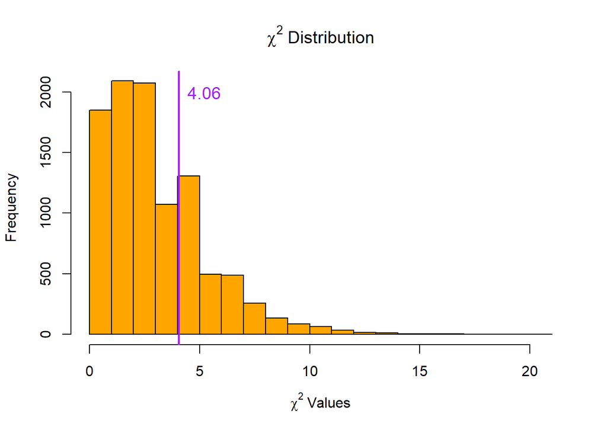

Figure 14: chi^2 ~ “Distribution”

```r
# Randomly create tables for Chi-square distribution
set.seed(1)
B = 10000

x_list = r2dtable(n = B,
                  r = rowSums(contingency_table2),
                  c = colSums(contingency_table2))

rnd.chisq = numeric(B)

for (i in 1:B) {
  rnd.chisq[i] = chisq.test(x_list[[i]])$statistic
}

# Create histogram
hist(rnd.chisq,
     col = "orange",
     xlab=expression(chi^2 ~ "Values"),
     main = bquote(chi^2 ~ "Distribution"))

abline(v = signif(chiqMF$statistic,3), col = "purple", lwd = 2)

text(x = signif(chiqMF$statistic, 3),
     y = max(hist(rnd.chisq, plot = FALSE)$counts) * 0.95,
     labels = round(signif(chiqMF$statistic, 3), 2),
     col = "purple",
     pos = 4,
     cex = 1.2)
```

5. **p-value**: $P(\chi^2_{df} \ge$ 4.1 ) = 0.291
6. **Decision**: Since the p-value is larger than the threshold value of 5%, we accept $H_0$ and conclude that there is not enough evidence to reject the claim that the proportion of students’ study hours quantiles are the same for both female students from Oceania and Asia.

## 3 Conclusion

Group projects are an important part of DATA2x02, therefore many people have an interest in seeking out the best teammates.

Here we have shown that there was a significant difference in mean WAM between DATA2002 and DATA2902 students, implying that DATA2902 students on average can be better teammates if we use WAM as an indicator of success.

We also have shown a relationship between assignment submission preference and grade aim, where students who took a more proactive approach to submission are more likely to aim for higher grade, also an indicator for being a good teammate.

However, the conclusion for whether there is any valid reason to choose teammates by their nationality is muddled. For female teammates, there seems to be no significant difference while for male teammates, Asian students often report higher study hours per week, an indicator for being a good teammate. Whether this difference is due to culture or simply response bias (most likely sensitive question) is unclear and beyond the scope of this report, warranting further investigation.

## 4 References

Firke, Sam. 2023. *Janitor: Simple Tools for Examining and Cleaning Dirty Data*. https://github.com/sfirke/janitor.

Iannone, Richard, Joe Cheng, Barret Schloerke, Ellis Hughes, Alexandra Lauer, JooYoung Seo, Ken Brevoort, and Olivier Roy. 2024. *Gt: Easily Create Presentation-Ready Display Tables*. https://gt.rstudio.com.

Kassambara, Alboukadel. 2023. *Ggpubr: Ggplot2 Based Publication Ready Plots*. https://rpkgs.datanovia.com/ggpubr/.

Pedersen, Thomas Lin. 2024. *Patchwork: The Composer of Plots*. https://patchwork.data-imaginist.com.

R Core Team. 2024. *R: A Language and Environment for Statistical Computing*. Vienna, Austria: R Foundation for Statistical Computing. https://www.R-project.org/.

Tarr, Garth. 2024a. “DATA2002 Assignment: Data Importing and Cleaning Guide.” 2024. https://pages.github.sydney.edu.au/DATA2002/2024/assignment/assignment_data.html.

———. 2024b. *DATA2x02 Class Survey*.

Tierney, Nicholas. 2023. *Visdat: Preliminary Visualisation of Data*. https://docs.ropensci.org/visdat/.

Wickham, Hadley. 2020. *Reshape2: Flexibly Reshape Data: A Reboot of the Reshape Package*. https://github.com/hadley/reshape.

Wickham, Hadley, Mara Averick, Jennifer Bryan, Winston Chang, Lucy D’Agostino McGowan, Romain François, Garrett Grolemund, et al. 2019. “Welcome to the tidyverse.” *Journal of Open Source Software* 4 (43): 1686. https://doi.org/10.21105/joss.01686.

Xie, Yihui, J. J. Allaire, and Garrett Grolemund. 2018. *R Markdown: The Definitive Guide*. Boca Raton, Florida: Chapman; Hall/CRC. https://bookdown.org/yihui/rmarkdown.